# The Zombie Checkpoint

Group 2 · Decision trees and unequal mistake costs

## The data and the baseline

**90 checkpoint records: 69 humans and 21 zombies**

- Predictors: body temperature, reaction time, groan volume, bite marks, and umbrella possession.
- Outcome: human or zombie.
- Default `rpart` classification tree, following the supplied R script.

Letting everyone in achieves **76.7% accuracy** while missing **all 21 zombies**.

## Body temperature drives the default tree

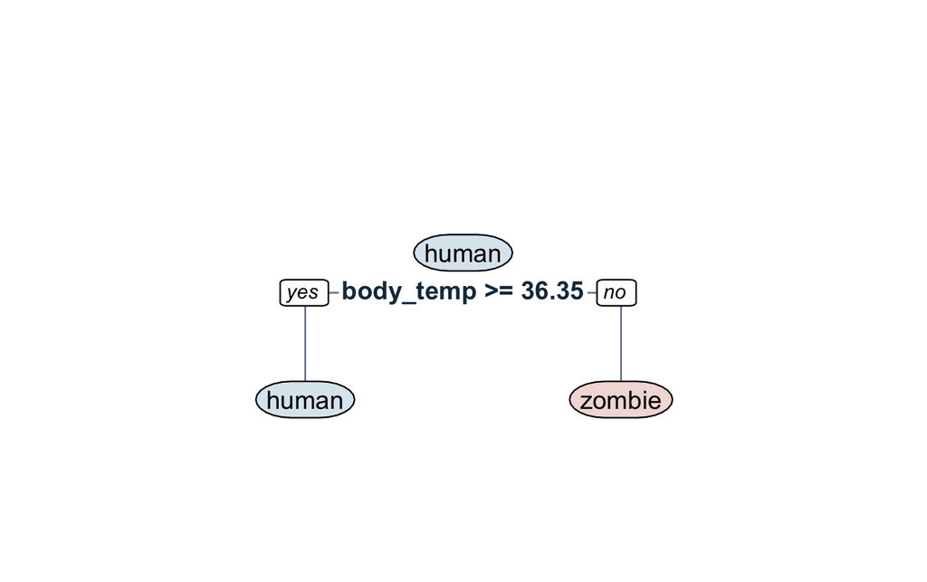

**Gate rules**

- Below **36.35°C**: quarantine.
- At or above **36.35°C**: admit.

Body temperature has the highest variable importance. Other signs do not enter this final tree.

Tree fitted to all 90 records. “Zombie” means quarantine, “human” means admit.

## The default tree misses two zombies

| Actual class | Admit: predicted human | Quarantine: predicted zombie |
| --- | --- | --- |
| Human | 66 | **3** |
| Zombie | **2** | 19 |

**94.4% accuracy** · **90.5% zombie recall**

Both missed zombies have a temperature of **36.7°C**. Their bite marks do not affect the default rule.

All 90 fitting records. Bold cells show mistakes. Recall = zombies caught / all zombies.

## A 10× penalty adds a bite-mark check

### Equal mistake costs

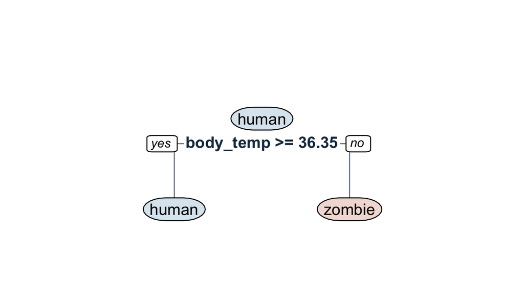

### Missing a zombie costs 10×

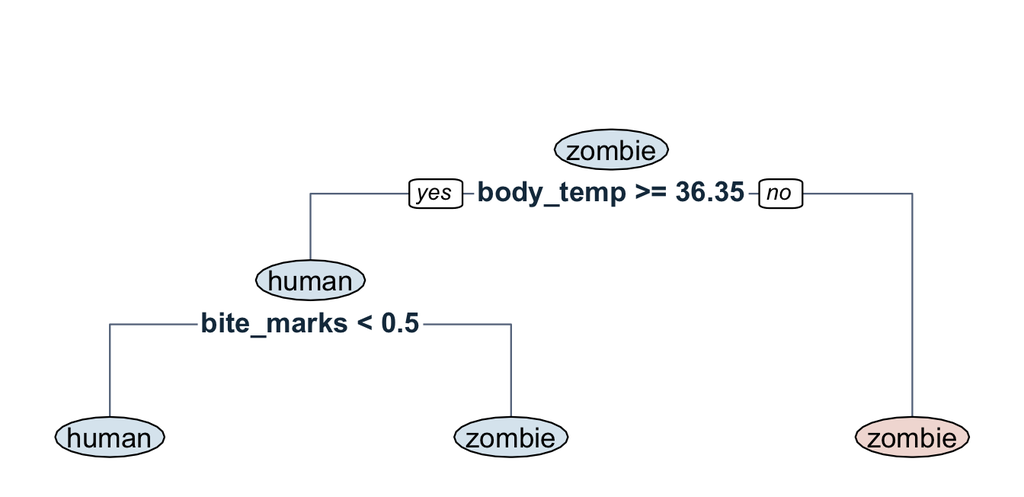

With the 10× loss, admit only people at or above **36.35°C** who have **zero bite marks**.

Both trees fit all 90 records. A bite-mark split at 0.5 separates zero from one or more.

## Fewer missed zombies, more humans in quarantine

### Equal costs

| Actual | Admit | Quarantine |
| --- | --- | --- |
| Human | 66 | **3** |
| Zombie | **2** | 19 |

### 10× loss

| Actual | Admit | Quarantine |
| --- | --- | --- |
| Human | 54 | **15** |
| Zombie | **0** | 21 |

| Measure | Equal costs | 10× loss |
| --- | --- | --- |
| Accuracy | 94.4% | 83.3% |
| Zombie recall | 90.5% | 100% |
| Cost: 10 × missed zombies + quarantined humans | 23 | 15 |

All 90 fitting records. The cost falls by 8 units under the assumed 10:1 ratio.

## The held-out test shows no improvement

Both models train on the **same 68 people** and predict the **same 22 unseen records**.

| Actual class | Admit: both trees | Quarantine: both trees |
| --- | --- | --- |
| Human | 18 | 0 |
| Zombie | **2** | 2 |

**90.9% accuracy** · **50% zombie recall** · **Cost 20**

Both trees retain only the temperature rule. The training set contains no zombies at or above 36.35°C.

Seed 301 and 75% sampling, as in graph.R. Only four zombies appear in the test set.

## The hardest cases look human

- Both missed zombies have normal-looking temperatures and reaction times that overlap human values.
- Bite marks help catch them in the full-data model, but the same rule also quarantines more humans.
- Early infection could explain subtle symptoms. The dataset cannot confirm that explanation.

Accuracy hides which mistakes the model makes. The cost ratio determines which tradeoff we prefer.

## Gate policy and real-world parallels

**Provisional choice:** the full-data 10× tree, if the town accepts the 10:1 cost ratio. Its fitting-record cost is lower, but the held-out test does not establish a benefit.

- Wrong quarantine still harms humans. Prompt review and retesting matter.
- Disease screening balances missed illness against unnecessary follow-up.
- Fraud detection balances missed fraud against blocked legitimate payments.

Before deployment, evaluate more representative cases and report both kinds of mistake alongside recall and cost.